# IMAGE SEGMENTATION WITH FCN

### Table of Contents

- 1 - Objectives
- 2 - Setup
- 3 - Data
- 4 - Pre-processing
- 5 - Build, compile and train a model
- 6 - Evaluation
- 7 - Annex
  - A - Size Factors
  - B - Custom Metric: IoU
- 8 - References

## **1. Introduction**

In this notebook, we explore image segmentation using Fully Convolutional Neural Networks (FCNs). The primary goal is learning: understanding the core concepts behind semantic segmentation, the architecture of FCNs, and how they can be trained.

## **2. Setup**

```python
import os
import zipfile
import PIL.Image, PIL.ImageFont, PIL.ImageDraw
from PIL import Image
import numpy as np
import tensorflow as tf
from matplotlib import pyplot as plt
import tensorflow_datasets as tfds
import seaborn as sns
import cv2
from sklearn.metrics import confusion_matrix
```

```python
tf.random.set_seed(5)
```

```python
from dataclasses import dataclass

# for default values
@dataclass
class DataConfig:
    batch_size: int = 16
    width: int = 224
    height: int = 224

G = DataConfig()
```

## **3. Data**

**Download data**

```python
#!pip install gdown
```

```python
# download the dataset (zipped file)
!mkdir data
!gdown --id 0B0d9ZiqAgFkiOHR1NTJhWVJMNEU -O data/fcnn-dataset.zip
```

```
mkdir: cannot create directory ‘data’: File exists
Downloading...
From (original): https://drive.google.com/uc?id=0B0d9ZiqAgFkiOHR1NTJhWVJMNEU
From (redirected): https://drive.google.com/uc?id=0B0d9ZiqAgFkiOHR1NTJhWVJMNEU&confirm=t&uuid=5e4d786e-700d-483e-8e1a-4f919665893b
To: /content/data/fcnn-dataset.zip
100% 126M/126M [00:01<00:00, 110MB/s]
```

```python
# extract the downloaded dataset to a local directory: /tmp/fcnn
local_zip = 'data/fcnn-dataset.zip'
zip_ref = zipfile.ZipFile(local_zip, 'r')
zip_ref.extractall('data/fcnn')
zip_ref.close()
```

```python
!ls data/fcnn/dataset1/
```

```
annotations_prepped_test   images_prepped_test
annotations_prepped_train  images_prepped_train
```

```python
train_img_dir = "data/fcnn/dataset1/images_prepped_train"
test_img_dir = "data/fcnn/dataset1/images_prepped_test"
train_annotation_dir = "data/fcnn/dataset1/annotations_prepped_train"
test_annotation_dir = "data/fcnn/dataset1/annotations_prepped_test"
```

**Understanding the data**

The dataset contains folders for images and annotations.

- The *images* contain the video frames.
- The *annotations* contain the pixel-wise label maps.
  - Each label map has the shape `(height, width , 1)` with each point in this space denoting the corresponding pixel's class.

Classes are in the range `[0, 11]` (i.e. 12 classes) and the pixel labels correspond to these classes:

| Value | Class Name |
| --- | --- |
| 0 | sky |
| 1 | building |
| 2 | column/pole |
| 3 | road |
| 4 | side walk |
| 5 | vegetation |
| 6 | traffic light |
| 7 | fence |
| 8 | vehicle |
| 9 | pedestrian |
| 10 | byciclist |
| 11 | void |

For example, if a pixel is part of a road, then that point will be labeled `3` in the label map.

```python
# pixel labels in the video frames
class_names = ['sky', 'building','column/pole', 'road', 'side walk', 'vegetation', 'traffic light',
               'fence', 'vehicle',
               'pedestrian', 'byciclist', 'void']

num_classes = len(class_names)
```

Let's visualize images and annotations:

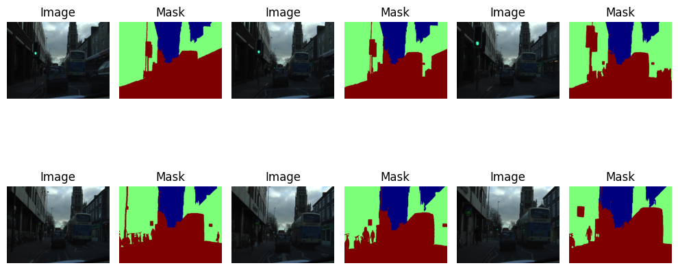

```python
# Number of samples to plot
num_samples_to_show = 6  # Multiple of 3 for even rows

# Get sample filenames
image_filenames = sorted(os.listdir(train_img_dir))[:num_samples_to_show]
mask_filenames = sorted(os.listdir(train_annotation_dir))[:num_samples_to_show]

# Plot settings
pairs_per_row = 3
fig, axs = plt.subplots(num_samples_to_show // pairs_per_row, pairs_per_row * 2,
                        figsize=(10,6))

for i, (img_file, mask_file) in enumerate(zip(image_filenames, mask_filenames)):
    # Load image and mask
    img = cv2.imread(os.path.join(train_img_dir, img_file))



    img = cv2.cvtColor(img, cv2.COLOR_BGR2RGB)
    mask = cv2.imread(os.path.join(train_annotation_dir, mask_file), cv2.IMREAD_GRAYSCALE)

    row = i // pairs_per_row
    col = (i % pairs_per_row) * 2

    axs[row, col].imshow(img)
    axs[row, col].set_title("Image")
    axs[row, col].axis("off")

    axs[row, col + 1].imshow(mask, cmap='jet', vmin=0, vmax=2)
    axs[row, col + 1].set_title("Mask")
    axs[row, col + 1].axis("off")

plt.tight_layout()
plt.show()
```

## **4. Pre-processing**

```python
def map_filename_to_image_and_mask(t_filename, a_filename, height=G.height, width=G.width, num_classes=num_classes):
    """
    Reads and preprocesses an image and its corresponding segmentation mask from given file paths.

    Args:
        t_filename (tf.Tensor or str): Path to the input image file.
        a_filename (tf.Tensor or str): Path to the corresponding annotation (mask) file.
        height (int): Target height to resize the image and mask. Defaults to G.height.
        width (int): Target width to resize the image and mask. Defaults to G.width.
        num_classes (int): Number of segmentation classes for one-hot encoding. Defaults to num_classes.

    Returns:
        image (tf.Tensor): Preprocessed image tensor of shape (height, width, 3), normalized to [-1, 1].
        annotation (tf.Tensor): One-hot encoded mask tensor of shape (height, width, num_classes).
    """

    # Read and decode the image (3 channels)
    img_raw = tf.io.read_file(t_filename)
    image = tf.image.decode_png(img_raw, channels=3)
    image = tf.image.resize(image, (height, width))  # Resize image to desired size
    image = tf.cast(image, tf.float32) / 127.5 - 1.0  # Normalize pixel values to [-1, 1]

    # Read and decode the annotation mask (1 channel)
    anno_raw = tf.io.read_file(a_filename)
    annotation = tf.image.decode_png(anno_raw, channels=1)
    annotation = tf.image.resize(annotation, (height, width), method='nearest')  # Keep class labels intact
    annotation = tf.cast(annotation, tf.int32)
    annotation = tf.squeeze(annotation, axis=-1)  # Remove channel dimension (H, W, 1) -> (H, W)

    # Convert annotation to one-hot format: shape becomes (H, W, num_classes)
    annotation = tf.one_hot(annotation, depth=num_classes)

    return image, annotation
```

**Creating TF Datasets**

First, we need a function that returns sorted file paths for images and their corresponding segmentation masks (label maps).

```python
def get_dataset_slice_paths(image_dir, label_map_dir):
    '''
    Returns sorted paths to image and mask files.
    '''
    image_file_list = sorted(os.listdir(image_dir))
    label_map_file_list = sorted(os.listdir(label_map_dir))

    image_paths = [os.path.join(image_dir, fname) for fname in image_file_list]
    label_map_paths = [os.path.join(label_map_dir, fname) for fname in label_map_file_list]

    return image_paths, label_map_paths
```

```python
def get_dataset(image_paths, label_map_paths, batch_size = G.batch_size, training=True):
  '''
    Args:
        image_paths (list of str): Paths to each image file in the dataset.
        label_map_paths (list of str): Paths to each label map file.
        batch_size (int): Number of samples per batch.
        training (bool): Whether the dataset is for training (enables shuffling).

    Returns:
        tf.data.Dataset: A dataset yielding batches of preprocessed images and masks.
  '''
  training_dataset = tf.data.Dataset.from_tensor_slices((image_paths, label_map_paths))
  training_dataset = training_dataset.map(map_filename_to_image_and_mask)
  if training:
      training_dataset = training_dataset.shuffle(100, reshuffle_each_iteration=True)
  training_dataset = training_dataset.batch(batch_size)

  return training_dataset
```

```python
# get the paths to the images
training_image_paths, training_label_map_paths = get_dataset_slice_paths(train_img_dir, train_annotation_dir)
test_image_paths, test_label_map_paths = get_dataset_slice_paths(test_img_dir, test_annotation_dir)

# generate the train and val sets
training_dataset = get_dataset(training_image_paths, training_label_map_paths)
validation_dataset = get_dataset(test_image_paths, test_label_map_paths, training=False)
```

```python
for x, y in training_dataset.take(1):
    print(x.shape, y.shape)
```

```
(16, 224, 224, 3) (16, 224, 224, 12)
```

```python
for x, y in validation_dataset.take(1):
    print(x.shape, y.shape)
```

```
(16, 224, 224, 3) (16, 224, 224, 12)
```

## **5. Build, compile and train a model**

We will build the following model:

[figure not shown]

First of all:

- As a good software engineering practice, we will create a function that returns a block consisting of several convolutional layers followed by a pooling layer.
- We will download the pretrained weights of VGG16.

```python
def block(x, n_convs, filters, kernel_size, activation, pool_size, pool_stride, block_name, padding='same'):
    """
    Creates a convolutional block consisting of multiple Conv2D layers followed by a MaxPooling2D layer.

    Parameters:
        -----------
        x : (tf.Tensor) -- Input tensor to the block.
        n_convs : (int) -- Number of convolutional layers to apply sequentially.
        filters : (int) -- Number of filters in each Conv2D layer.
        kernel_size : (int or tuple) -- Size of the convolution kernel.
        activation : (str or callable) -- Activation function to use in the Conv2D layers.
        pool_size : (int or tuple) -- Size of the max pooling window.
        pool_stride : (int or tuple) -- Stride of the max pooling operation.
        block_name : (str) -- Base name for the layers in this block (used for naming Conv2D and MaxPooling2D layers).
        padding : (str, optional) (default='same') -- Padding method for Conv2D layers ('same' or 'valid').

    Returns:
    --------
        tf.Tensor - Output tensor after applying the convolutional layers and max pooling.
    """

    for i in range(n_convs):
        x = tf.keras.layers.Conv2D(filters=filters,
                                   kernel_size=kernel_size,
                                   activation=activation,
                                   padding=padding,
                                   name=f"{block_name}_conv{i+1}"
                                  )(x)

    x = tf.keras.layers.MaxPooling2D(pool_size=pool_size,
                                     strides=pool_stride,
                                     name=f"{block_name}_pool{i+1}"
                                    )(x)

    return x
```

```python
# download the weights
!wget https://github.com/fchollet/deep-learning-models/releases/download/v0.1/vgg16_weights_tf_dim_ordering_tf_kernels_notop.h5

# assign to a variable
vgg_weights_path = "vgg16_weights_tf_dim_ordering_tf_kernels_notop.h5"
```

[output not shown]

**Encoder**: VGG-16

We will use 5 blocks, each consisting of a certain number of 2D convolutional layers followed by a max pooling layer with a pool size of (2, 2) and a stride of (2, 2).

Since the convolutional layers use padding='same', only the max pooling layers affect the input size.

The input size is 224×224, and each max pooling layer with pool_size=(2, 2) and stride=(2, 2) reduces the spatial dimensions by half.

The reduction in input size through the blocks is shown in the following table.

| Block | Operation | Size (HxW) |
| --- | --- | --- |
| Input |  | 224×224 |
| Block 1 | 2 convs + pool(2×2) | 112×112 |
| Block 2 | 2 convs + pool(2×2) | 56×56 |
| Block 3 | 3 convs + pool(2×2) | 28×28 |
| Block 4 | 3 convs + pool(2×2) | 14×14 |
| Block 5 | 3 convs + pool(2×2) | **7×7** |

As we can see, after passing through all 5 blocks, the input image size is reduced to 7×7.

```python
def VGG_16(image_input):
    ''' This function defines the VGG encoder.

    Args:
        image_input (tensor) - batch of images

    Returns:
        tuple of tensors - output of all encoder blocks plus the final convolution layer
    '''

    # create 5 blocks with increasing filters at each stage.
    x = block(image_input,
              n_convs=2,
              filters=64,
              kernel_size=(3,3),
              activation='relu',
              pool_size=(2,2),
              pool_stride=(2,2),
              block_name='block1')
    p1= x

    x = block(x,
              n_convs=2,
              filters=128,
              kernel_size=(3,3),
              activation='relu',
              pool_size=(2,2),
              pool_stride=(2,2),
              block_name='block2')
    p2 = x

    x = block(x,
              n_convs=3,
              filters=256,
              kernel_size=(3,3),
              activation='relu',
              pool_size=(2,2),
              pool_stride=(2,2),
              block_name='block3')
    p3 = x

    x = block(x,
              n_convs=3,
              filters=512,
              kernel_size=(3,3),
              activation='relu',
              pool_size=(2,2),
              pool_stride=(2,2),
              block_name='block4')
    p4 = x

    x = block(x,
              n_convs=3,
              filters=512,
              kernel_size=(3,3),
              activation='relu',
              pool_size=(2,2),
              pool_stride=(2,2),
              block_name='block5')
    p5 = x

    # create the vgg model
    vgg  = tf.keras.Model(image_input , p5)

    # load the pretrained weights you downloaded earlier
    vgg.load_weights(vgg_weights_path)

    # number of filters for the output convolutional layers
    n = 4096

    # our input images are 224x224 pixels so they will be downsampled to 7x7 after the pooling layers above.
    # we can extract more features by chaining two more convolution layers.
    c6 = tf.keras.layers.Conv2D(n, (7, 7), activation='relu', padding='same', name="conv6")(p5)
    c7 = tf.keras.layers.Conv2D(n, (1, 1), activation='relu', padding='same', name="conv7")(c6)

    # return the outputs at each stage
    return (p1, p2, p3, p4, c7)
```

**Decoder**: FCN-8

```python
def fcn8_decoder(convs, n_classes):
    ''' Defines the FCN 8 decoder.

    Args:
        convs (tuple of tensors): output of the encoder network (f1, f2, f3, f4, f5)
        n_classes (int): number of classes

    Returns:
        tensor with shape (height, width, n_classes) containing class probabilities
    '''

    f1, f2, f3, f4, f5 = convs

    # Upsample f5 (final encoder layer output) and crop to remove extra pixels
    score_pool5 = tf.keras.layers.Conv2DTranspose(
        n_classes, kernel_size=(4, 4), strides=(2, 2), use_bias=False)(f5)
    score_pool5 = tf.keras.layers.Cropping2D(cropping=(1, 1))(score_pool5)

    # 1x1 convolution on pool4 to reshape channels to n_classes
    score_pool4 = tf.keras.layers.Conv2D(
        n_classes, kernel_size=(1, 1), activation='relu', padding='same')(f4)

    # Add upsampled pool5 and pool4 predictions
    fuse_pool4 = tf.keras.layers.Add()([score_pool5, score_pool4])

    # Upsample fused pool4 features and crop
    upsampled_fuse_pool4 = tf.keras.layers.Conv2DTranspose(
        n_classes, kernel_size=(4, 4), strides=(2, 2), use_bias=False)(fuse_pool4)
    upsampled_fuse_pool4 = tf.keras.layers.Cropping2D(cropping=(1, 1))(upsampled_fuse_pool4)

    # 1x1 convolution on pool3 to reshape channels to n_classes
    score_pool3 = tf.keras.layers.Conv2D(
        n_classes, kernel_size=(1, 1), activation='relu', padding='same')(f3)

    # Add upsampled fused pool4 and pool3 predictions
    fuse_pool3 = tf.keras.layers.Add()([upsampled_fuse_pool4, score_pool3])

    # Upsample to original image size
    upsampled_output = tf.keras.layers.Conv2DTranspose(
        n_classes, kernel_size=(8, 8), strides=(8, 8), use_bias=False)(fuse_pool3)

    # Apply softmax to get class probabilities
    output = tf.keras.layers.Activation('softmax')(upsampled_output)

    return output
```

**Putting everything together**

```python
def segmentation_model():
    ''' Defines the final segmentation model by chaining together the encoder and decoder.

    Returns:
        keras Model that connects the encoder and decoder networks of the segmentation model
    '''

    inputs = tf.keras.layers.Input(shape=(224,224,3,))
    convs = VGG_16(image_input=inputs)
    outputs = fcn8_decoder(convs, 12)
    model = tf.keras.Model(inputs=inputs, outputs=outputs)

    return model
```

**Instantiate the model**

```python
# instantiate the model and see how it looks
model = segmentation_model()
model.summary()
```

```
Model: "functional_1"
```

```
┏━━━━━━━━━━━━━━━━━━━━━┳━━━━━━━━━━━━━━━━━━━┳━━━━━━━━━━━━┳━━━━━━━━━━━━━━━━━━━┓
┃ Layer (type)        ┃ Output Shape      ┃    Param # ┃ Connected to      ┃
┡━━━━━━━━━━━━━━━━━━━━━╇━━━━━━━━━━━━━━━━━━━╇━━━━━━━━━━━━╇━━━━━━━━━━━━━━━━━━━┩
│ input_layer         │ (None, 224, 224,  │          0 │ -                 │
│ (InputLayer)        │ 3)                │            │                   │
├─────────────────────┼───────────────────┼────────────┼───────────────────┤
│ block1_conv1        │ (None, 224, 224,  │      1,792 │ input_layer[0][0] │
│ (Conv2D)            │ 64)               │            │                   │
├─────────────────────┼───────────────────┼────────────┼───────────────────┤
│ block1_conv2        │ (None, 224, 224,  │     36,928 │ block1_conv1[0][… │
│ (Conv2D)            │ 64)               │            │                   │
├─────────────────────┼───────────────────┼────────────┼───────────────────┤
│ block1_pool2        │ (None, 112, 112,  │          0 │ block1_conv2[0][… │
│ (MaxPooling2D)      │ 64)               │            │                   │
├─────────────────────┼───────────────────┼────────────┼───────────────────┤
│ block2_conv1        │ (None, 112, 112,  │     73,856 │ block1_pool2[0][… │
│ (Conv2D)            │ 128)              │            │                   │
├─────────────────────┼───────────────────┼────────────┼───────────────────┤
│ block2_conv2        │ (None, 112, 112,  │    147,584 │ block2_conv1[0][… │
│ (Conv2D)            │ 128)              │            │                   │
├─────────────────────┼───────────────────┼────────────┼───────────────────┤
│ block2_pool2        │ (None, 56, 56,    │          0 │ block2_conv2[0][… │
│ (MaxPooling2D)      │ 128)              │            │                   │
├─────────────────────┼───────────────────┼────────────┼───────────────────┤
│ block3_conv1        │ (None, 56, 56,    │    295,168 │ block2_pool2[0][… │
│ (Conv2D)            │ 256)              │            │                   │
├─────────────────────┼───────────────────┼────────────┼───────────────────┤
│ block3_conv2        │ (None, 56, 56,    │    590,080 │ block3_conv1[0][… │
│ (Conv2D)            │ 256)              │            │                   │
├─────────────────────┼───────────────────┼────────────┼───────────────────┤
│ block3_conv3        │ (None, 56, 56,    │    590,080 │ block3_conv2[0][… │
│ (Conv2D)            │ 256)              │            │                   │
├─────────────────────┼───────────────────┼────────────┼───────────────────┤
│ block3_pool3        │ (None, 28, 28,    │          0 │ block3_conv3[0][… │
│ (MaxPooling2D)      │ 256)              │            │                   │
├─────────────────────┼───────────────────┼────────────┼───────────────────┤
│ block4_conv1        │ (None, 28, 28,    │  1,180,160 │ block3_pool3[0][… │
│ (Conv2D)            │ 512)              │            │                   │
├─────────────────────┼───────────────────┼────────────┼───────────────────┤
│ block4_conv2        │ (None, 28, 28,    │  2,359,808 │ block4_conv1[0][… │
```

[output cut: 41 more lines]

```
│ cropping2d_1        │ (None, 28, 28,    │          0 │ conv2d_transpose… │
│ (Cropping2D)        │ 12)               │            │                   │
├─────────────────────┼───────────────────┼────────────┼───────────────────┤
│ conv2d_1 (Conv2D)   │ (None, 28, 28,    │      3,084 │ block3_pool3[0][… │
│                     │ 12)               │            │                   │
├─────────────────────┼───────────────────┼────────────┼───────────────────┤
│ add_1 (Add)         │ (None, 28, 28,    │          0 │ cropping2d_1[0][… │
│                     │ 12)               │            │ conv2d_1[0][0]    │
├─────────────────────┼───────────────────┼────────────┼───────────────────┤
│ conv2d_transpose_2  │ (None, 224, 224,  │      9,216 │ add_1[0][0]       │
│ (Conv2DTranspose)   │ 12)               │            │                   │
├─────────────────────┼───────────────────┼────────────┼───────────────────┤
│ activation          │ (None, 224, 224,  │          0 │ conv2d_transpose… │
│ (Activation)        │ 12)               │            │                   │
└─────────────────────┴───────────────────┴────────────┴───────────────────┘
```

```
 Total params: 135,067,736 (515.24 MB)
```

```
 Trainable params: 135,067,736 (515.24 MB)
```

```
 Non-trainable params: 0 (0.00 B)
```

**Compile and Training**

Custom Metric: Mean IoU

```python
class CustomMeanIoU(tf.keras.metrics.Metric):
    """
    Custom implementation of Mean Intersection over Union (Mean IoU) metric for semantic segmentation.

    This metric calculates the IoU for each class using the accumulated confusion matrix across batches
    and returns the mean IoU over all classes.

    Args:
        num_classes (int): Number of classes in the segmentation task.
        name (str): Optional name for the metric.
        **kwargs: Additional keyword arguments passed to the base class.

    Usage:
        metric = CustomMeanIoU(num_classes=3)
        model.compile(optimizer, loss, metrics=[metric])
    """

    def __init__(self, num_classes, name="custom_mean_iou", **kwargs):
        super().__init__(name=name, **kwargs)
        self.num_classes = num_classes
        # Accumulated confusion matrix across batches
        self.confusion_matrix = self.add_weight(
            name="confusion_matrix",
            shape=(num_classes, num_classes),
            initializer="zeros",
            dtype=tf.float32
        )

    def update_state(self, y_true, y_pred, sample_weight=None):
        """
        Update the confusion matrix given the ground truth and predictions for the current batch.
        """
        y_pred = tf.argmax(y_pred, axis=-1)  # Convert logits or probabilities to class predictions

        # If y_true is one-hot encoded, convert it to integer labels
        if y_true.shape.rank is not None and y_true.shape.rank == y_pred.shape.rank + 1:
            y_true = tf.argmax(y_true, axis=-1)

        # Flatten both tensors to compute the confusion matrix
        y_true = tf.reshape(y_true, [-1])
        y_pred = tf.reshape(y_pred, [-1])

        # Compute batch confusion matrix
        cm = tf.math.confusion_matrix(
            y_true,
            y_pred,
            num_classes=self.num_classes,
            dtype=tf.float32
        )
        # Accumulate confusion matrix
        self.confusion_matrix.assign_add(cm)

    def result(self):
        """
        Compute the mean IoU across all classes from the accumulated confusion matrix.
        """
        sum_over_row = tf.reduce_sum(self.confusion_matrix, axis=0)  # Predicted labels per class
        sum_over_col = tf.reduce_sum(self.confusion_matrix, axis=1)  # True labels per class
        true_positives = tf.linalg.diag_part(self.confusion_matrix)  # Correct predictions per class
        denominator = sum_over_row + sum_over_col - true_positives  # Union per class

        iou = tf.math.divide_no_nan(true_positives, denominator)  # IoU per class
        return tf.reduce_mean(iou)  # Mean IoU

    def reset_states(self):
        """
        Reset the confusion matrix to zeros at the beginning of a new epoch or evaluation.
        """
        tf.keras.backend.set_value(
            self.confusion_matrix,
            tf.zeros((self.num_classes, self.num_classes), dtype=tf.float32)
        )
```

**Compile and training**

```python
from tensorflow.keras.callbacks import EarlyStopping, ReduceLROnPlateau

# Compile the model
model.compile(
    loss='categorical_crossentropy',  # softmax activation in final layer
    optimizer='adam',
    metrics=[
        CustomMeanIoU(num_classes=num_classes),
        tf.keras.metrics.CategoricalAccuracy(name="pixel_accuracy")
    ]
)

# Callbacks
callbacks = [
    EarlyStopping(monitor='val_loss', patience=25, restore_best_weights=True),
    ReduceLROnPlateau(monitor='val_loss', factor=0.5, patience=3, verbose=1)
]
```

```python
history = model.fit(
    training_dataset,
    validation_data=validation_dataset,
    epochs=150,
    callbacks=callbacks
)
```

```
23/23 ━━━━━━━━━━━━━━━━━━━━ 105s 3s/step - custom_mean_iou: 0.0354 - loss: 2.5764 - pixel_accuracy: 0.1058 - val_custom_mean_iou: 0.0459 - val_loss: 2.1696 - val_pixel_accuracy: 0.2651 - learning_rate: 0.0010
23/23 ━━━━━━━━━━━━━━━━━━━━ 13s 539ms/step - custom_mean_iou: 0.0515 - loss: 1.9536 - pixel_accuracy: 0.3191 - val_custom_mean_iou: 0.1023 - val_loss: 1.5975 - val_pixel_accuracy: 0.5007 - learning_rate: 0.0010
23/23 ━━━━━━━━━━━━━━━━━━━━ 13s 542ms/step - custom_mean_iou: 0.1127 - loss: 1.5209 - pixel_accuracy: 0.5058 - val_custom_mean_iou: 0.1538 - val_loss: 1.2612 - val_pixel_accuracy: 0.5796 - learning_rate: 0.0010
23/23 ━━━━━━━━━━━━━━━━━━━━ 13s 535ms/step - custom_mean_iou: 0.1718 - loss: 1.1185 - pixel_accuracy: 0.6354 - val_custom_mean_iou: 0.1653 - val_loss: 1.1626 - val_pixel_accuracy: 0.5838 - learning_rate: 0.0010
23/23 ━━━━━━━━━━━━━━━━━━━━ 20s 507ms/step - custom_mean_iou: 0.1904 - loss: 1.0214 - pixel_accuracy: 0.6464 - val_custom_mean_iou: 0.1718 - val_loss: 1.1748 - val_pixel_accuracy: 0.5891 - learning_rate: 0.0010
23/23 ━━━━━━━━━━━━━━━━━━━━ 12s 516ms/step - custom_mean_iou: 0.2015 - loss: 0.9890 - pixel_accuracy: 0.6630 - val_custom_mean_iou: 0.1677 - val_loss: 1.1793 - val_pixel_accuracy: 0.5830 - learning_rate: 0.0010
23/23 ━━━━━━━━━━━━━━━━━━━━ 13s 542ms/step - custom_mean_iou: 0.2121 - loss: 0.9381 - pixel_accuracy: 0.6712 - val_custom_mean_iou: 0.1827 - val_loss: 1.1040 - val_pixel_accuracy: 0.6040 - learning_rate: 0.0010
23/23 ━━━━━━━━━━━━━━━━━━━━ 13s 540ms/step - custom_mean_iou: 0.2219 - loss: 0.8979 - pixel_accuracy: 0.6869 - val_custom_mean_iou: 0.1894 - val_loss: 1.0562 - val_pixel_accuracy: 0.6091 - learning_rate: 0.0010
23/23 ━━━━━━━━━━━━━━━━━━━━ 20s 531ms/step - custom_mean_iou: 0.2324 - loss: 0.8815 - pixel_accuracy: 0.6857 - val_custom_mean_iou: 0.2094 - val_loss: 1.0521 - val_pixel_accuracy: 0.6239 - learning_rate: 0.0010
23/23 ━━━━━━━━━━━━━━━━━━━━ 13s 534ms/step - custom_mean_iou: 0.2391 - loss: 0.8634 - pixel_accuracy: 0.7011 - val_custom_mean_iou: 0.2122 - val_loss: 0.9894 - val_pixel_accuracy: 0.6263 - learning_rate: 0.0010
23/23 ━━━━━━━━━━━━━━━━━━━━ 13s 544ms/step - custom_mean_iou: 0.2560 - loss: 0.8107 - pixel_accuracy: 0.7189 - val_custom_mean_iou: 0.2153 - val_loss: 0.9628 - val_pixel_accuracy: 0.6388 - learning_rate: 0.0010
23/23 ━━━━━━━━━━━━━━━━━━━━ 13s 535ms/step - custom_mean_iou: 0.2751 - loss: 0.7797 - pixel_accuracy: 0.7453 - val_custom_mean_iou: 0.2365 - val_loss: 0.9346 - val_pixel_accuracy: 0.6581 - learning_rate: 0.0010
23/23 ━━━━━━━━━━━━━━━━━━━━ 13s 541ms/step - custom_mean_iou: 0.2915 - loss: 0.7516 - pixel_accuracy: 0.7572 - val_custom_mean_iou: 0.2683 - val_loss: 0.8195 - val_pixel_accuracy: 0.7259 - learning_rate: 0.0010
23/23 ━━━━━━━━━━━━━━━━━━━━ 20s 536ms/step - custom_mean_iou: 0.3089 - loss: 0.6863 - pixel_accuracy: 0.7838 - val_custom_mean_iou: 0.2953 - val_loss: 0.7664 - val_pixel_accuracy: 0.7645 - learning_rate: 0.0010
23/23 ━━━━━━━━━━━━━━━━━━━━ 13s 536ms/step - custom_mean_iou: 0.3109 - loss: 0.6895 - pixel_accuracy: 0.7856 - val_custom_mean_iou: 0.2956 - val_loss: 0.7613 - val_pixel_accuracy: 0.7669 - learning_rate: 0.0010
23/23 ━━━━━━━━━━━━━━━━━━━━ 13s 544ms/step - custom_mean_iou: 0.3196 - loss: 0.6685 - pixel_accuracy: 0.7892 - val_custom_mean_iou: 0.3325 - val_loss: 0.6568 - val_pixel_accuracy: 0.8060 - learning_rate: 0.0010
23/23 ━━━━━━━━━━━━━━━━━━━━ 13s 536ms/step - custom_mean_iou: 0.3468 - loss: 0.5902 - pixel_accuracy: 0.8165 - val_custom_mean_iou: 0.3448 - val_loss: 0.6205 - val_pixel_accuracy: 0.8156 - learning_rate: 0.0010
23/23 ━━━━━━━━━━━━━━━━━━━━ 13s 543ms/step - custom_mean_iou: 0.3604 - loss: 0.5785 - pixel_accuracy: 0.8192 - val_custom_mean_iou: 0.3647 - val_loss: 0.5819 - val_pixel_accuracy: 0.8299 - learning_rate: 0.0010
23/23 ━━━━━━━━━━━━━━━━━━━━ 13s 535ms/step - custom_mean_iou: 0.3734 - loss: 0.5409 - pixel_accuracy: 0.8309 - val_custom_mean_iou: 0.3734 - val_loss: 0.5723 - val_pixel_accuracy: 0.8267 - learning_rate: 0.0010
23/23 ━━━━━━━━━━━━━━━━━━━━ 13s 541ms/step - custom_mean_iou: 0.3826 - loss: 0.5171 - pixel_accuracy: 0.8364 - val_custom_mean_iou: 0.3835 - val_loss: 0.5386 - val_pixel_accuracy: 0.8441 - learning_rate: 0.0010
23/23 ━━━━━━━━━━━━━━━━━━━━ 13s 535ms/step - custom_mean_iou: 0.3997 - loss: 0.4951 - pixel_accuracy: 0.8446 - val_custom_mean_iou: 0.3951 - val_loss: 0.5195 - val_pixel_accuracy: 0.8412 - learning_rate: 0.0010
23/23 ━━━━━━━━━━━━━━━━━━━━ 21s 534ms/step - custom_mean_iou: 0.4073 - loss: 0.4691 - pixel_accuracy: 0.8505 - val_custom_mean_iou: 0.4107 - val_loss: 0.4906 - val_pixel_accuracy: 0.8515 - learning_rate: 0.0010
23/23 ━━━━━━━━━━━━━━━━━━━━ 20s 512ms/step - custom_mean_iou: 0.4225 - loss: 0.4355 - pixel_accuracy: 0.8615 - val_custom_mean_iou: 0.4107 - val_loss: 0.4926 - val_pixel_accuracy: 0.8478 - learning_rate: 0.0010
23/23 ━━━━━━━━━━━━━━━━━━━━ 13s 540ms/step - custom_mean_iou: 0.4309 - loss: 0.4380 - pixel_accuracy: 0.8598 - val_custom_mean_iou: 0.4121 - val_loss: 0.4802 - val_pixel_accuracy: 0.8495 - learning_rate: 0.0010
23/23 ━━━━━━━━━━━━━━━━━━━━ 20s 516ms/step - custom_mean_iou: 0.4429 - loss: 0.4145 - pixel_accuracy: 0.8674 - val_custom_mean_iou: 0.4042 - val_loss: 0.4931 - val_pixel_accuracy: 0.8455 - learning_rate: 0.0010
23/23 ━━━━━━━━━━━━━━━━━━━━ 20s 511ms/step - custom_mean_iou: 0.4589 - loss: 0.3882 - pixel_accuracy: 0.8758 - val_custom_mean_iou: 0.4035 - val_loss: 0.4863 - val_pixel_accuracy: 0.8466 - learning_rate: 0.0010
```

[output cut: 49 more lines]

## **6. Evaluation**

```python
def compute_per_class_iou(y_true, y_pred, num_classes):
    y_true = np.argmax(y_true, axis=-1).flatten()
    y_pred = np.argmax(y_pred, axis=-1).flatten()

    cm = confusion_matrix(y_true, y_pred, labels=np.arange(num_classes))

    iou_per_class = []
    for i in range(num_classes):
        TP = cm[i, i]
        FP = cm[:, i].sum() - TP
        FN = cm[i, :].sum() - TP
        denom = TP + FP + FN
        iou = TP / denom if denom != 0 else 0
        iou_per_class.append(iou)

    return iou_per_class
```

```python
# Predict on validation set
y_trues, y_preds = [], []

for images, masks in validation_dataset:
    preds = model.predict(images)
    y_trues.append(masks.numpy())
    y_preds.append(preds)

# Concatenate all batches
y_trues = np.concatenate(y_trues, axis=0)
y_preds = np.concatenate(y_preds, axis=0)

# Compute per-class IoU
ious = compute_per_class_iou(y_trues, y_preds, num_classes=num_classes)

# Print nicely
for i, iou in enumerate(ious):
    print(f"Class {i}: IoU = {iou:.4f}")
```

```
1/1 ━━━━━━━━━━━━━━━━━━━━ 1s 1s/step
1/1 ━━━━━━━━━━━━━━━━━━━━ 0s 247ms/step
1/1 ━━━━━━━━━━━━━━━━━━━━ 0s 281ms/step
1/1 ━━━━━━━━━━━━━━━━━━━━ 0s 282ms/step
1/1 ━━━━━━━━━━━━━━━━━━━━ 0s 222ms/step
1/1 ━━━━━━━━━━━━━━━━━━━━ 0s 210ms/step
1/1 ━━━━━━━━━━━━━━━━━━━━ 1s 916ms/step
Class 0: IoU = 0.9154
Class 1: IoU = 0.7594
Class 2: IoU = 0.0000
Class 3: IoU = 0.9359
Class 4: IoU = 0.7522
Class 5: IoU = 0.8650
Class 6: IoU = 0.0629
Class 7: IoU = 0.5013
Class 8: IoU = 0.4310
Class 9: IoU = 0.1149
Class 10: IoU = 0.1699
Class 11: IoU = 0.1437
```

**Analysis**

🔎 Conclusion: The model performs well on a few classes, but struggles or completely fails on others. We may need to:

- Check class distribution,
- Improve data diversity,
- Apply techniques like focal loss, class weighting, or data augmentation.

```python
def visualize_prediction(image_resized, true_mask, pred_mask, original_shape=(360,480)):
    # Resize masks back to original size with nearest neighbor
    true_mask_resized = tf.image.resize(tf.expand_dims(true_mask, -1), original_shape, method='nearest')
    pred_mask_resized = tf.image.resize(tf.expand_dims(pred_mask, -1), original_shape, method='nearest')

    # Squeeze to remove channel dimension
    true_mask_resized = tf.squeeze(true_mask_resized).numpy().astype(np.uint8)
    pred_mask_resized = tf.squeeze(pred_mask_resized).numpy().astype(np.uint8)

    # Resize input image back to original size
    image_original = tf.image.resize(image_resized, original_shape)
    # If image is float [0,1], scale to uint8
    if image_original.dtype.is_floating:
        image_original = (image_original.numpy() * 255).astype(np.uint8)
    else:
        image_original = image_original.numpy()

    plt.figure(figsize=(15,5))

    plt.subplot(1,3,1)
    plt.imshow(image_original)
    plt.title("Original Image")
    plt.axis('off')

    plt.subplot(1,3,2)
    plt.imshow(true_mask_resized, cmap='tab20', vmin=0, vmax=11)
    plt.title("True Mask")
    plt.axis('off')

    plt.subplot(1,3,3)
    plt.imshow(pred_mask_resized, cmap='tab20', vmin=0, vmax=11)
    plt.title("Predicted Mask")
    plt.axis('off')

    plt.show()
```

```
1/1 ━━━━━━━━━━━━━━━━━━━━ 3s 3s/step
```

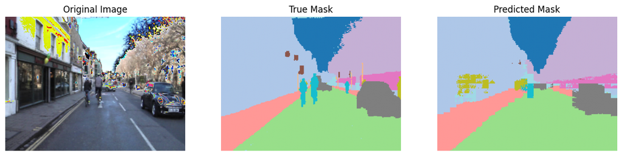

```python
# Extract sample from batch
for x_batch, y_batch in validation_dataset.take(1):
    image_resized = x_batch[3]
    true_mask = tf.argmax(y_batch[3], axis=-1)  # from one-hot to class indices
    pred = model.predict(tf.expand_dims(image_resized, axis=0))[0]
    pred_mask = tf.argmax(pred, axis=-1)
    break

visualize_prediction(image_resized, true_mask, pred_mask, original_shape=(360,480))
```

## **Annex**

### **Size Factors**

For an input of size H × W, pool size P, and stride S, the output size is:

```
Output Height = ⌊(H - P) / S⌋ + 1
Output Width  = ⌊(W - P) / S⌋ + 1
```

In a more general way:

Let:

- Input size: H_in × W_in
- Pool size: (P_h, P_w) (height, width)
- Stride: (S_h, S_w) (height, width)

Then the output size is:

```
Output Height = ⌊(H_in - P_h) / S_h⌋ + 1
Output Width  = ⌊(W_in - P_w) / S_w⌋ + 1
```

```python
def test_max_pooling(input_shape, pool_size, strides):
    # Create a random input tensor with the given shape
    x = tf.random.normal(shape=(1, *input_shape, 1))  # Batch size 1, 1 channel
    print(f"Input shape: {x.shape}")

    # Define max pooling layer
    pool = tf.keras.layers.MaxPooling2D(pool_size=pool_size, strides=strides)

    # Apply pooling
    y = pool(x)
    print(f"Pool size: {pool_size}, Strides: {strides}")
    print(f"Output shape: {y.shape}\n")
```

**Case 1:** pool_size = (2, 2), strides = (2, 2) Input:

- Height = 32
- Width = 32

```
Output Height = ⌊(32 - 2) / 2⌋ + 1 = 16
Output Width  = ⌊(32 - 2) / 2⌋ + 1 = 16
```

```python
test_max_pooling((32, 32), pool_size=(2, 2), strides=(2, 2))  # square pool/stride
```

```
Input shape: (1, 32, 32, 1)
Pool size: (2, 2), Strides: (2, 2)
Output shape: (1, 16, 16, 1)
```

**Case 2:** pool_size = (2, 3), strides = (2, 2) Input:

- Height = 32
- Width = 28

```
Output Height = ⌊(32 - 2) / 2⌋ + 1 = 16
Output Width  = ⌊(28 - 3) / 2⌋ + 1 = 13
```

```python
test_max_pooling((32, 28), pool_size=(2, 3), strides=(2, 2))  # non-square pool
```

```
Input shape: (1, 32, 28, 1)
Pool size: (2, 3), Strides: (2, 2)
Output shape: (1, 16, 13, 1)
```

**Case 3:** pool_size = (2, 3), strides = (1, 1) Input:

- Height = 32
- Width = 28

```
Output Height = ⌊(32 - 2) / 1⌋ + 1 = 31
Output Width  = ⌊(28 - 3) / 1⌋ + 1 = 26
```

```python
test_max_pooling((32, 28), pool_size=(2, 3), strides=(1, 1))  # non-square pool, stride 1
```

```
Input shape: (1, 32, 28, 1)
Pool size: (2, 3), Strides: (1, 1)
Output shape: (1, 31, 26, 1)
```

### **Custom Metric: Mean IoU**

Let's test our custom Mean IoU:

```python
# --- Simulate predictions and labels ---
num_classes = 3
batch = 2
height = 2
width = 2

# Fake softmax predictions: shape (batch, H, W, C)
y_pred = tf.random.uniform((batch, height, width, num_classes))
y_pred = tf.nn.softmax(y_pred, axis=-1)

# Fake one-hot ground truth
y_true_int = tf.random.uniform((batch, height, width), maxval=num_classes, dtype=tf.int32)
y_true = tf.one_hot(y_true_int, depth=num_classes)

# --- Use custom metric standalone ---
metric = CustomMeanIoU(num_classes=num_classes)

# Update state (like model would after 1 batch)
metric.update_state(y_true, y_pred)

# Print result
print(y_pred)
print(y_true)
print("Mean IoU:", metric.result().numpy())
```

```
tf.Tensor(
[[[[0.24373096 0.52758294 0.2286861 ]
   [0.24697179 0.41837168 0.3346565 ]]

  [[0.29569644 0.25839025 0.44591329]
   [0.43099308 0.29003814 0.27896872]]]


 [[[0.24632408 0.4364375  0.3172384 ]
   [0.35798097 0.28732097 0.35469803]]

  [[0.18474025 0.4048921  0.41036767]
   [0.41476345 0.33037496 0.25486156]]]], shape=(2, 2, 2, 3), dtype=float32)
tf.Tensor(
[[[[0. 0. 1.]
   [0. 0. 1.]]

  [[0. 0. 1.]
   [0. 0. 1.]]]


 [[[0. 0. 1.]
   [1. 0. 0.]]

  [[1. 0. 0.]
   [0. 0. 1.]]]], shape=(2, 2, 2, 3), dtype=float32)
Mean IoU: 0.13095237
```

## **References**

[TF Advanced Techniques Specialization](https://www.coursera.org/specializations/tensorflow-advanced-techniques)